# Datos del INE con R

Programación y manejo de datos con R (Slides 04-C)

Pedro J. Pérez

pedro.j.perez@uv.es

## ¿Qué es el INE?

- El [Instituto Nacional de Estadística](https://www.ine.es/) (**INE**) es el organismo público encargado de la estadística oficial en España
- Hace las grandes estadísticas del país: el censo y el padrón, el IPC, la EPA, la Contabilidad Nacional, …
- Para nosotros, lo importante:  
  (casi) todos sus datos son públicos y gratuitos.  
  Están en [**INEbase**](https://www.ine.es/dyngs/INEbase/listaoperaciones.htm), su base de datos,  
  agrupados por temas  
  (*Economía*, *Mercado laboral*, …)

[figure not shown]

Si necesitas un dato sobre España (población, precios, empleo, turismo, renta, …), lo más probable es que lo tenga el INE

## Las operaciones estadísticas

- El INE organiza su trabajo en **operaciones estadísticas**: cada una es una estadística concreta, con su metodología y su periodicidad

| Operación | Código | ¿Qué mide? | Periodicidad |
| --- | --- | --- | --- |
| Índice de Precios de Consumo | `IPC` | los precios (la inflación) | mensual |
| Encuesta de Población Activa | `EPA` | ocupados, parados, tasa de paro, … | trimestral |
| Contabilidad Nacional Trimestral | `CNTR2010` | el PIB y sus componentes | trimestral |
| Padrón municipal | `DPOP` | la población de cada municipio | anual |
| Encuesta de Condiciones de Vida | `ECV` | renta, pobreza y desigualdad | anual |

- El código de la operación lo usaremos después con el paquete `ineapir` … pero ojo, solo sirve para ver qué **tablas** tiene esa operación. Los datos se descargan con el identificador de la tabla, que es un número (lo vemos enseguida)

## ¿Cómo están organizados los datos?

- Los datos del INE están organizados en operaciones y tablas. Veámoslo con la EPA:

| Nivel | ¿Qué es? | En la EPA |
| --- | --- | --- |
| **Operación** | una estadística se identifica con un código de letras | `EPA` la Encuesta de Población Activa |
| **Tabla** | dentro de cada operación hay muchas tablas se identifican con un número | `65334` *tasas de paro por edad, sexo y comunidad autónoma* |

- Las tablas contienen **series**. Por ejemplo, la tabla `65334` tiene 5 columnas:
  - tres “**variables**”: *Sexo* (3 categorías), *Edad* (7) y *Comunidad autónoma* (20)
  - el periodo (*2026T3*, *2026T2*, …)
  - el dato (`Total`)

| Sexo | CC.AA. | Edad | Periodo | Total |
| --- | --- | --- | --- | --- |
| Ambos sexos | Total Nacional | Total | 2026T3 | 10,18 |
| Ambos sexos | Total Nacional | Total | 2026T2 | 9,87 |
| Ambos sexos | Total Nacional | Total | 2026T1 | 10,83 |

- Por lo tanto, la tabla `65334` contiene 3 × 7 × 20 = 420 series, cada una con un dato por trimestre desde 2002.

  Una serie de esas 420 es la de los valores (tasa de paro) para las *Mujeres*, *Menores de 25 años* de la *Comunitat Valenciana*

## Tres formas de conseguir los datos

1. **Por menús**: entras en la web, eliges la tabla, pinchas en el botón de descarga y guardas el fichero
2. **Con la url del fichero**: descargas el fichero desde R, sin pasar por la web
3. **Con la API**: le pides los datos directamente al INE desde R, con el paquete `ineapir`
- Como con Eurostat, la primera forma no es reproducible: nadie sabe qué has pinchado. Con las otras dos, el script contiene todo el proceso

Veremos primero cómo hacerlo “a mano” (formas 1 y 2) y después con `ineapir`

## Los datos, a mano

Descargar un fichero del INE (CSV o PC-Axis) y limpiarlo

## Cada tabla tiene su página, su identificador … y varios formatos

- Queremos la **tasa de paro por comunidades autónomas**. Buscando en INEbase (*Mercado laboral* → *EPA* → …) llegamos a la [página de la tabla](https://www.ine.es/jaxiT3/Tabla.htm?t=65334)
- El número del final de la url es el **identificador de la tabla**: `65334`. Apúntalo, lo vamos a necesitar!!
- El botón de descarga ofrece varios formatos. ¿Cuál elegimos?

[figure not shown]

| Formato | ¿Cómo es? | ¿Sirve para R? |
| --- | --- | --- |
| **CSV separado por ;** | una fila por dato | sí, es el mejor |
| Excel (`.xlsx`) | la tabla tal como se ve en la web, con títulos y notas | con mucho trabajo |
| **PC-Axis** (`.px`) | los datos y sus metadatos (título, unidades, notas, …) | sí, y muy bien, con el paquete `pxR` |
| Json | el formato de la API | mejor con `ineapir` |

Pero … no hace falta pinchar en el botón: la url del fichero siempre tiene la misma forma. Solo cambian el formato y el identificador de la tabla:  
`https://www.ine.es/jaxiT3/files/t/es/``csv_bdsc``/``65334``.csv` (el PC-Axis: `.../es/px/65334.px`)

## Descargamos el fichero, lo importamos … y aparece un problema

```r
my_url  <- "https://www.ine.es/jaxiT3/files/t/es/csv_bdsc/65334.csv"
my_ruta <- here::here("pruebas", "epa_65334.csv")
curl::curl_download(my_url, my_ruta)
```

**1**

Guardamos el fichero en la carpeta `pruebas`, que tiene que existir (`fs::dir_create("pruebas")`)

- Antes de importarlo, míralo: ¿cómo es por dentro?

```r
read_lines(my_ruta, n_max = 3)
```

```
#> [1] "Sexo;Comunidades y Ciudades Autónomas;Edad;Periodo;Total"
#> [2] "Ambos sexos;Total Nacional;Total;2026T3;10,18"
#> [3] "Ambos sexos;Total Nacional;Total;2026T2;9,87"
```

- Es un CSV “a la española”: las columnas se separan con `;` y los decimales llevan coma. Lo importamos con `read_csv2()`:

```r
df_epa <- read_csv2(my_ruta)

df_epa %>% slice(1:3)
```

| Sexo <chr> | Comunidades y Ciudades Autónomas <chr> | Edad <chr> | Periodo <chr> | Total <chr> |
| --- | --- | --- | --- | --- |
| Ambos sexos | Total Nacional | Total | 2026T3 | 10,18 |
| Ambos sexos | Total Nacional | Total | 2026T2 | 9,87 |
| Ambos sexos | Total Nacional | Total | 2026T1 | 10,83 |

- `Periodo` es texto (normal: `2026T2` no es un número), pero … ¡`Total` también es texto! Debería ser un número

## ¿Por qué `Total` no es numérica?

- Porque el INE marca con `..` los datos que no publica (grupos con muy pocas personas en la muestra).  
  Basta con que haya un `..` en la columna para que toda ella se importe como texto
- Solución: decirle a `read_csv2()` que `..` significa “no hay dato” (`NA`):

```r
df_epa <- read_csv2(my_ruta, na = "..")

df_epa %>% slice(1:3)
```

| Sexo <chr> | Comunidades y Ciudades Autónomas <chr> | Edad <chr> | Periodo <chr> | Total <dbl> |
| --- | --- | --- | --- | --- |
| Ambos sexos | Total Nacional | Total | 2026T3 | 10.18 |
| Ambos sexos | Total Nacional | Total | 2026T2 | 9.87 |
| Ambos sexos | Total Nacional | Total | 2026T1 | 10.83 |

- Si no sabes qué valor es el que molesta, puedes buscarlo: `df_epa %>% filter(is.na(parse_number(Total))) %>% count(Total)`

## Limpiamos los datos … y ya podemos usarlos

```r
df_epa_2 <- df_epa %>%
  janitor::clean_names() %>%
  rename(ccaa = comunidades_y_ciudades_autonomas,
         tasa_paro = total) %>%
  mutate(fecha = lubridate::yq(periodo)) %>%
  mutate(ccaa = if_else(ccaa == "Total Nacional",
                        "00 Total Nacional", ccaa)) %>%
  separate(ccaa, into = c("ccaa_cod", "ccaa"),
           sep = " ", extra = "merge") %>%
  select(fecha, periodo, ccaa_cod, ccaa,
         sexo, edad, tasa_paro)
```

**1**

Nombres de columnas “cómodos”: en minúsculas, sin espacios y sin tildes

**2**

Nombres más cortos y que digan qué hay en la columna

**3**

`2026T2` pasa a ser una fecha de verdad: `2026-04-01` (el primer día del trimestre)

**4**

`Total Nacional` es la única sin código delante: le ponemos `00`, como si fuera una comunidad más

**5**

La columna lleva el código y el nombre juntos (`10 Comunitat Valenciana`): los separamos por el primer espacio (con `extra = "merge"`, el resto va junto al nombre)

- O, con expresiones regulares (en lugar de `if_else()` y `separate()`):

```r
df_epa_2 <- df_epa %>%
  janitor::clean_names() %>%
  rename(ccaa = comunidades_y_ciudades_autonomas,
         tasa_paro = total) %>%
  mutate(fecha = lubridate::yq(periodo)) %>%
  mutate(ccaa_cod = str_extract(ccaa, "^[0-9]{2}"),
         ccaa = str_remove(ccaa, "^[0-9]{2} ")) %>%
  select(fecha, periodo, ccaa_cod, ccaa,
         sexo, edad, tasa_paro)
```

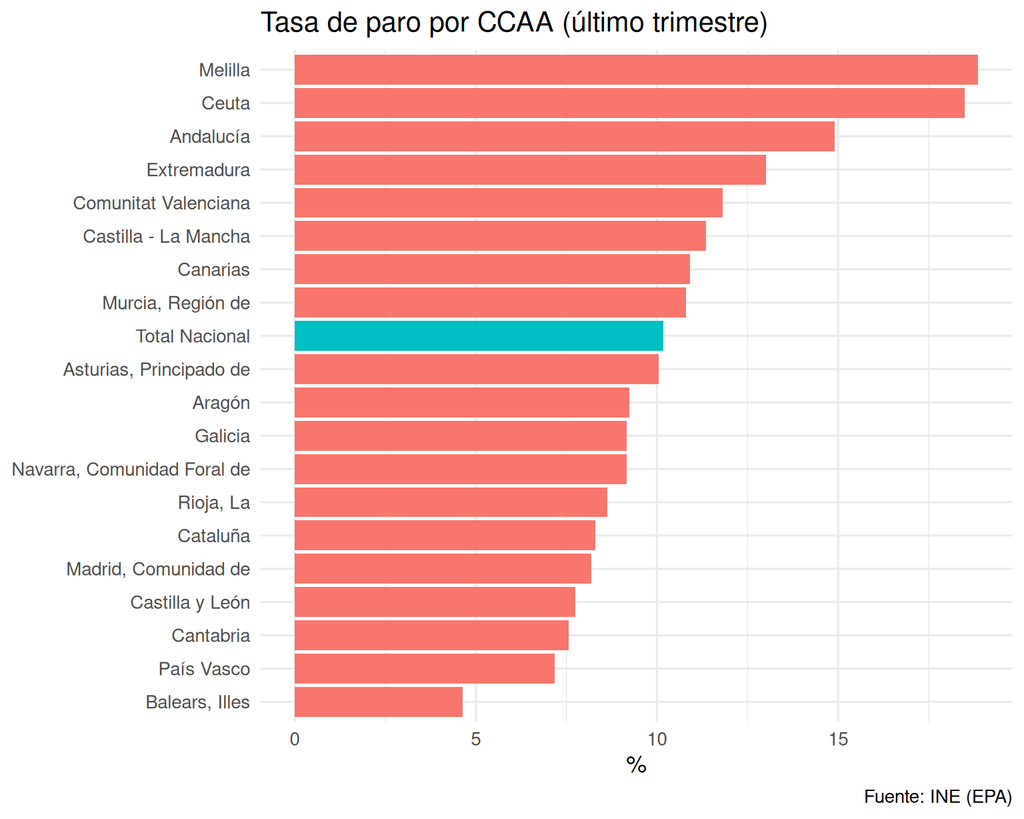

```r
df_epa_2 %>%
  filter(sexo == "Ambos sexos", edad == "Total") %>%
  filter(fecha == max(fecha)) %>%
  ggplot(aes(x = tasa_paro, y = fct_reorder(ccaa, tasa_paro))) +
  geom_col(aes(fill = ccaa == "Total Nacional"),
           show.legend = FALSE) +
  labs(title = "Tasa de paro por CCAA (último trimestre)",
       x = "%", y = NULL, caption = "Fuente: INE (EPA)")
```

## Trampas habituales en los ficheros del INE

| Trampa | Ejemplo | Solución |
| --- | --- | --- |
| separador `;` y coma decimal | `9,87` | `read_csv2()` |
| datos no disponibles | `..` | `read_csv2(..., na = "..")` |
| código y nombre en la misma columna | `10 Comunitat Valenciana` | `separate()` o `str_extract()` |
| el periodo no es una fecha | `2026T2`, `2026M09` | `lubridate::yq()`, `lubridate::ym()` |
| los totales mezclados con las categorías | `Total Nacional`, `Ambos sexos` | `filter()`: cuidado al sumar |

Después de importar, comprueba siempre el tipo de cada columna y cuenta sus categorías con `count()`.  
Y una regla: del INE, nunca el Excel. Mejor el **CSV separado por ;** o, como vamos a ver ahora, el **PC-Axis**

## El formato PC-Axis (`.px`) y el paquete `pxR`

- **PC-Axis** es un formato pensado para publicar tablas estadísticas: además de los datos, lleva sus **metadatos** (título, unidades, “variables”, notas, …). En R lo lee el paquete [`pxR`](https://cran.r-project.org/package=pxR)

```r
my_url_px <- "https://www.ine.es/jaxiT3/files/t/es/px/65334.px"

px_epa <- pxR::read.px(my_url_px)
df_px  <- px_epa %>% as.data.frame() %>% as_tibble()
```

**1**

Lee el fichero directamente de la url (o del disco). Devuelve un objeto de clase `px`, con los datos y los metadatos

**2**

Con `as.data.frame()` sacamos los datos del objeto `px`

```r
df_px %>% slice(1:3)
```

| Periodo <fct> | Edad <fct> | Comunidades.y.Ciudades.Autónomas <fct> | Sexo <fct> | value <dbl> |
| --- | --- | --- | --- | --- |
| 2026T3 | Total | Total Nacional | Ambos sexos | 10.18 |
| 2026T2 | Total | Total Nacional | Ambos sexos | 9.87 |
| 2026T1 | Total | Total Nacional | Ambos sexos | 10.83 |

- Sin decirle nada: una fila por dato, `value` ya es numérica, los `..` ya son `NA` y las tildes están bien. Las variables llegan como factores (con las categorías en el orden de la web)

## Además de los datos, los metadatos

- El objeto `px` guarda todo lo que el INE cuenta sobre la tabla:

```r
px_epa$TITLE$value
```

```
#> [1] "Tasas de paro por distintos grupos de edad, sexo y comunidad autónoma"
```

```r
px_epa$UNITS$value
```

```
#> [1] "Tasas"
```

```r
names(px_epa$VALUES)               #- las "variables" de la tabla
```

```
#> [1] "Sexo"                             "Comunidades.y.Ciudades.Autónomas"
#> [3] "Edad"                             "Periodo"
```

```r
px_epa$VALUES$Edad                 #- los valores de una "variable"
```

```
#> [1] "Total"              "Menores de 25 años" "25 y más años"      "De 16 a 19 años"
#> [5] "De 20 a 24 años"    "De 25 a 54 años"    "De 55 y más años"
```

```r
px_epa$NOTE$value %>% str_trunc(110)
```

```
#> [1] "Los resultados de Ceuta y Melilla deben tomarse con precaución porque pueden \"\n\"estar afectados por grandes..."
```

- Muy útil para poner bien el título, las unidades y la fuente de tus tablas y gráficos … y para leer las notas, que suelen avisar de cambios metodológicos

## ¿CSV o PC-Axis?

|  | CSV con `read_csv2()` | PC-Axis con `pxR` |
| --- | --- | --- |
| separador, decimales, tildes | hay que acertar con la función | automático |
| datos no disponibles (`..`) | `na = ".."` | automático |
| título, unidades, notas | no vienen | sí |
| tipo de las variables | texto | factores |
| el periodo y los códigos | hay que limpiarlos | hay que limpiarlos |

Un fichero del INE: léelo con `pxR::read.px()` (o con `read_csv2()`, con cuidado). Y después, comprueba y limpia

Ojo!! Usa siempre `pxR::read.px()` y nunca hagas `library(pxR)`: carga el paquete `plyr`, que tapa varias funciones de `dplyr` (`mutate()`, `summarise()`, `arrange()`, `count()`, `rename()`). Tu código seguiría funcionando … pero haciendo otra cosa!!

## Tarea: los municipios de la provincia de Valencia

- Tarea
- Pistas
- Solución (1-3)
- Solución (4)
- Solución (5)
- La tabla [`2903`](https://www.ine.es/jaxiT3/Tabla.htm?t=2903) del INE tiene la población de los municipios de la provincia de Valencia, año a año, según el Padrón
1. Descarga desde R el fichero CSV (separado por `;`) de la tabla e impórtalo
2. Mira qué hay en cada columna. ¿De qué tipo es cada una? ¿Qué categorías tiene `Sexo`?
3. Limpia los datos: nombres de columna cómodos, y el código y el nombre del municipio en dos columnas
4. ¿Cuáles son los 5 municipios con más población en el último año?
5. [🌶] ¿Qué 5 municipios han ganado más habitantes (en %) entre 2015 y el último año? Quédate solo con los que tenían más de 5.000 habitantes en 2015
- 1: la url es como la de la EPA, cambiando el identificador de la tabla
- 2: `count(Sexo)`. Fíjate en la población: en el fichero lleva punto de miles (`1.015`)
- 3: `separate()`: el código y el nombre están separados por el primer espacio
- 4: cuidado, hay una fila que no es un municipio: el total de la provincia (`46 Valencia/València`)
- 5: `filter()` + `group_by()` + `summarise()` con `first()` y `last()`

```r
my_url <- "https://www.ine.es/jaxiT3/files/t/es/csv_bdsc/2903.csv"

df_pob <- read_csv2(my_url) %>%
  janitor::clean_names() %>%
  rename(anyo = periodo, poblacion = total) %>%
  separate(municipios, into = c("muni_cod", "muni"),
           sep = " ", extra = "merge") %>%
  filter(muni_cod != "46") %>%
  select(anyo, muni_cod, muni, sexo, poblacion)
```

**1**

`read_csv2()` también lee directamente de una url

**2**

Quitamos el total de la provincia (`46 Valencia/València`): su código es el de la provincia, `46`

```r
df_pob %>%
  slice(1:3) %>%
  gt::gt() %>%
  gt::fmt_number(columns = poblacion,
                 decimals = 0, sep_mark = ".")
```

| anyo | muni_cod | muni | sexo | poblacion |
| --- | --- | --- | --- | --- |
| 2025 | 46001 | Ademuz | Total | 1.015 |
| 2024 | 46001 | Ademuz | Total | 1.004 |
| 2023 | 46001 | Ademuz | Total | 1.004 |

```r
df_top5 <- df_pob %>%
  filter(sexo == "Total", anyo == max(anyo)) %>%
  slice_max(poblacion, n = 5)
```

```r
df_top5 %>%
  gt::gt() %>%
  gt::fmt_number(columns = poblacion,
                 decimals = 0, sep_mark = ".")
```

| anyo | muni_cod | muni | sexo | poblacion |
| --- | --- | --- | --- | --- |
| 2025 | 46250 | València | Total | 840.792 |
| 2025 | 46244 | Torrent | Total | 90.928 |
| 2025 | 46131 | Gandia | Total | 83.135 |
| 2025 | 46190 | Paterna | Total | 76.019 |
| 2025 | 46220 | Sagunt/Sagunto | Total | 73.031 |

```r
df_crec <- df_pob %>%
  filter(sexo == "Total", anyo %in% c(2015, max(anyo))) %>%
  arrange(anyo) %>%
  group_by(muni) %>%
  summarise(pob_2015 = first(poblacion),
            pob_hoy  = last(poblacion)) %>%
  filter(pob_2015 > 5000) %>%
  mutate(crec = pob_hoy / pob_2015 - 1) %>%
  slice_max(crec, n = 5)
```

```r
df_crec %>%
  gt::gt() %>%
  gt::fmt_number(columns = c(pob_2015, pob_hoy),
                 decimals = 0, sep_mark = ".") %>%
  gt::fmt_percent(columns = crec, decimals = 1)
```

| muni | pob_2015 | pob_hoy | crec |
| --- | --- | --- | --- |
| San Antonio de Benagéber | 7.981 | 11.192 | 40.2% |
| Montserrat | 7.231 | 10.062 | 39.2% |
| Nàquera/Náquera | 6.204 | 8.556 | 37.9% |
| Canet d'En Berenguer | 6.426 | 8.297 | 29.1% |
| Bétera | 22.349 | 28.560 | 27.8% |

## Un mapa de España por provincias, con `mapSpain`

- El paquete [`mapSpain`](https://ropenspain.github.io/mapSpain/) tiene las geometrías de España (CCAA, provincias, municipios, …)

```r
my_url <- "https://www.ine.es/jaxiT3/files/t/es/csv_bdsc/65349.csv"

df_prov <- read_csv2(my_url, na = "..") %>%
  janitor::clean_names() %>%
  filter(sexo == "Ambos sexos", periodo == max(periodo),
         tasas == "Tasa de paro de la población") %>%
  mutate(cpro = str_extract(provincias, "^[0-9]{2}"))


geo_prov <- mapSpain::esp_get_prov()


mapa_prov <- geo_prov %>% left_join(df_prov, by = "cpro")
```

**1**

La tabla `65349` de la EPA: tasas de actividad, paro y empleo por provincia

**2**

El código de la provincia: las 2 cifras del principio (`46 Valencia/València`)

**3**

Las geometrías de las provincias. Su código está en la columna `cpro`

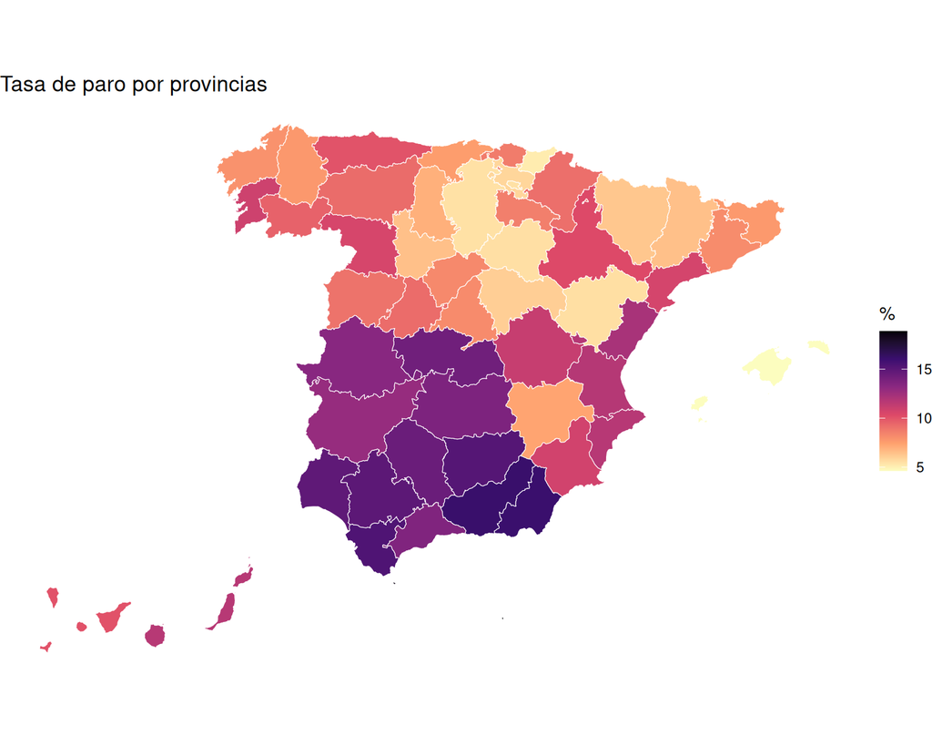

```r
ggplot(mapa_prov) +
  geom_sf(aes(fill = total), color = "white") +
  scale_fill_viridis_c(option = "magma",
                       direction = -1) +
  labs(title = "Tasa de paro por provincias",
       fill = "%") +
  theme_void()
```

## … y por municipios

- Con los datos de la tarea (`df_pob`): ¿cuánto ha crecido la población de cada municipio de la provincia de Valencia desde 2015?

```r
df_crec_muni <- df_pob %>%
  filter(sexo == "Total", anyo %in% c(2015, max(anyo))) %>%
  arrange(anyo) %>%
  group_by(muni_cod) %>%
  summarise(crec = last(poblacion) / first(poblacion) - 1)


geo_muni <- mapSpain::esp_get_munic(
              region = "Valencia/València") %>%
  mutate(muni_cod = paste0(cpro, cmun))


mapa_muni <- geo_muni %>% left_join(df_crec_muni, by = "muni_cod")
```

**1**

Las geometrías de los municipios de la provincia de Valencia

**2**

El código de municipio del INE (5 cifras) es el de la provincia (`cpro`) más el del municipio (`cmun`)

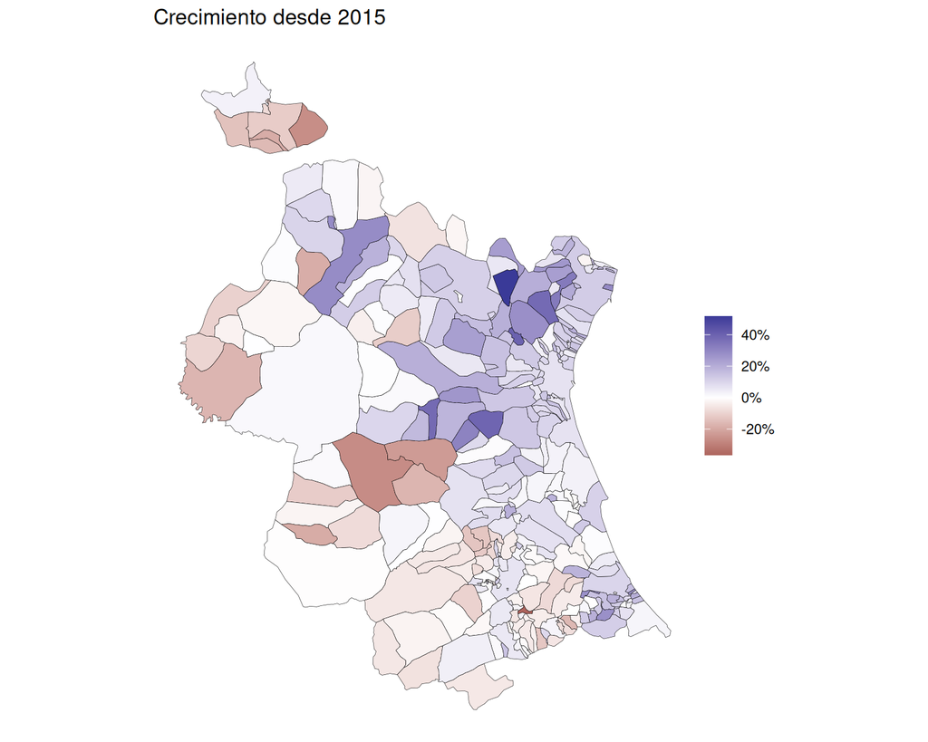

```r
ggplot(mapa_muni) +
  geom_sf(aes(fill = crec), color = "black",
          linewidth = 0.1) +
  scale_fill_gradient2(
    labels = scales::label_percent()) +
  labs(title = "Crecimiento desde 2015",
       fill = NULL) +
  theme_void()
```

## El paquete *ineapir*

Los datos del INE, directamente desde R

## [`ineapir`](https://es-ine.github.io/ineapir/) es el paquete del INE para descargar sus datos desde R

- Usa la [API](https://www.ine.es/dyngs/DAB/index.htm?cid=1099) del INE (un servicio al que un programa le pide datos con una url), pero sin tener que escribir las url

```r
library(ineapir)     #- si no lo tienes instalado: pak::pak("ineapir")
```

- Ventajas frente a descargar ficheros:
  - puedes buscar operaciones y tablas desde R
  - puedes pedir solo lo que necesitas: los últimos datos, unas fechas, unas categorías
  - los datos llegan con sus metadatos
- Tiene una [web](https://es-ine.github.io/ineapir/) con muchos ejemplos y una [*cheatsheet*](https://raw.githubusercontent.com/es-ine/ineapir/main/man/figures/ineapir.pdf)

| Para … | función |
| --- | --- |
| ver las operaciones | `get_metadata_operations()` |
| ver las tablas de una operación | `get_metadata_tables_operation()` |
| ver las “variables” de una tabla | `get_metadata_table_groups()` |
| ver los valores de una “variable” | `get_metadata_table_values()` |
| **descargar una tabla** | `get_data_table()` |

**El recorrido habitual**: operación → tabla → (“variables” y valores) → datos

Si ya conoces el identificador de la tabla (el `t=` de la url), puedes ir directamente a `get_data_table()`

## Paso 1: ¿qué operaciones hay?

```r
operaciones <- get_metadata_operations()

operaciones %>% select(Id, Nombre, Codigo) %>% slice(1:3)
```

| Id <int> | Nombre <chr> | Codigo <chr> |
| --- | --- | --- |
| 6 | Índice de Coste Laboral Armonizado | ICLA |
| 7 | Estadística de Transmisión de Derechos de la Propiedad | ETDP |
| 8 | Censos de Población y Viviendas | CENSOPV |

- La API ofrece 166 operaciones. Para buscar una, filtramos por su nombre:

```r
operaciones %>%
  filter(str_detect(Nombre, "Población Activa")) %>%
  select(Id, Nombre, Codigo)
```

| Id <int> | Nombre <chr> | Codigo <chr> |
| --- | --- | --- |
| 205 | Flujos de la Población Activa | EFPA |
| 293 | Encuesta de Población Activa (EPA) | EPA |

- Lo que necesitamos es el `Codigo`: `EPA`, `IPC`, …

## Paso 2: ¿qué tablas tiene una operación?

```r
tablas_ipc <- get_metadata_tables_operation(operation = "IPC")

tablas_ipc %>% select(Id, Nombre, Anyo_Periodo_ini) %>% slice(1:3)
```

| Id <int> | Nombre <chr> | Anyo_Periodo_ini <chr> |
| --- | --- | --- |
| 24077 | Índice general nacional. Series desde enero de 1961 | 1961 |
| 24080 | Índice nacionales de grupos ECOICOP. Series desde enero de 1993 | 1993 |
| 35083 | Índices nacionales: Componentes para el análisis de la COVID-19 | 2017 |

- El IPC tiene 59 tablas. Buscamos la que nos interesa: el índice general y los grupos, a nivel nacional

```r
tablas_ipc %>%
  filter(str_detect(Nombre,
                    "Índices nacionales: general")) %>%
  select(Id, Nombre)
```

| Id <int> | Nombre <chr> |
| --- | --- |
| 76125 | Índices nacionales: general y de grupos ECOICOP ver.2 |
| 79181 | Índices nacionales: general y de grupos ECOICOP ver.2 |
| 76144 | Índices nacionales: general y de grupos ECOICOP ver.2 |
| 25333 | Índices nacionales: general y de grupos ECOICOP |

- Hay varias con el mismo nombre (distintas bases del IPC). Nos quedamos con la `76125`: es la que sale en [INEbase](https://www.ine.es/jaxiT3/Tabla.htm?t=76125)

## Paso 3: descargamos la tabla

- Ya sabemos el identificador de la tabla (la `76125`). La descargamos con `get_data_table()`:

```r
df <- get_data_table(idTable = 76125,
                     nlast = 2,
                     unnest = TRUE,
                     tip = "A")
```

**1**

La tabla que queremos

**2**

Solo los 2 últimos periodos. Sin `nlast` se descarga la tabla completa

**3**

Una fila por dato. Sin `unnest = TRUE` los datos llegan “escondidos” en una columna-lista

**4**

Nombres y fechas que se entienden (`"A"` de *amigable*), en lugar de códigos internos del INE. La fecha llega como texto: con `as.Date()` pasa a ser una fecha

```r
df %>%
  mutate(fecha = as.Date(Fecha)) %>%
  select(Nombre, fecha, Valor) %>%
  slice(1:3)
```

| Nombre <chr> | fecha <date> | Valor <dbl> |
| --- | --- | --- |
| Nacional. Índice general. Índice. | 2026-09-01 | 104.98 |
| Nacional. Índice general. Índice. | 2026-08-01 | 104.64 |
| Nacional. Índice general. Variación mensual. | 2026-09-01 | 0.3 |

## ¿Qué periodos queremos?

- Los últimos `n` periodos, con `nlast`:

```r
df <- get_data_table(idTable = 76125, nlast = 12, unnest = TRUE, tip = "A")
```

- Un rango de fechas, con `dateStart` y `dateEnd` (en formato `"aaaa/mm/dd"`). Si solo ponemos `dateStart`, llega hasta el último dato disponible:

```r
df <- get_data_table(idTable = 76125,
        unnest = TRUE, tip = "A",
        dateStart = "2025/01/01",
        dateEnd   = "2025/12/31")

df %>%
  mutate(fecha = as.Date(Fecha)) %>%
  summarise(desde = min(fecha), hasta = max(fecha),
            filas = n())
```

| desde <date> | hasta <date> | filas <int> |
| --- | --- | --- |
| 2025-01-01 | 2025-12-01 | 672 |

Sin `nlast` ni fechas se descarga la tabla entera: en tablas grandes puede tardar bastante

## El problema de la columna `Nombre`

- En `Nombre` está todo junto: el territorio, el grupo y el tipo de dato

```r
df %>% distinct(Nombre) %>% slice(1:3)
```

| Nombre <chr> |
| --- |
| Nacional. Índice general. Índice. |
| Nacional. Índice general. Variación mensual. |
| Nacional. Índice general. Variación anual. |

- Podríamos separarlo con `separate()`, pero hay una forma “mejor”:  
  pedir los metadatos con `tip = "AM"` y `metanames = TRUE`

```r
df <- get_data_table(idTable = 76125, nlast = 2, unnest = TRUE,
                     tip = "AM", metanames = TRUE)

df %>% as_tibble() %>%
  select(Nombre, Grupos.ECOICOP.ver.2, Tipo.de.dato, Valor) %>% slice(1:2)
```

**1**

Con `metanames = TRUE` se añade una columna por cada “variable” de la tabla. ¿Y «Nacional»? No tiene columna: en esta tabla todos los datos son nacionales, así que el territorio no es una “variable” de la tabla

| Nombre <chr> | Grupos.ECOICOP.ver.2 <chr> | Tipo.de.dato <chr> | Valor <dbl> |
| --- | --- | --- | --- |
| Nacional. Índice general. Índice. | Índice general | Índice | 104.98 |
| Nacional. Índice general. Índice. | Índice general | Índice | 104.64 |

## Antes de filtrar: ¿qué “variables” y qué valores tiene la tabla?

```r
#- las "variables" de la tabla:
get_metadata_table_groups(idTable = 76125)
```

| Id <int> | Nombre <chr> |
| --- | --- |
| 155577 | Grupos ECOICOP ver.2 |
| 155578 | Tipo de dato |

```r
#- los valores de "Grupos ECOICOP" (idGroup = su Id):
get_metadata_table_values(idTable = 76125,
                          idGroup = 155577) %>%
  select(Id, Fk_Variable, Nombre)
```

| Id <int> | Fk_Variable <int> | Nombre <chr> |
| --- | --- | --- |
| 304092 | 762 | Índice general |
| 304093 | 762 | Alimentos y bebidas no alcohólicas |

Primeras 2 filas de 14

```r
#- los de "Tipo de dato":
get_metadata_table_values(idTable = 76125,
                          idGroup = 155578) %>%
  select(Id, Fk_Variable, Nombre)
```

| Id <int> | Fk_Variable <int> | Nombre <chr> |
| --- | --- | --- |
| 83 | 3 | Índice |
| 84 | 3 | Variación mensual |
| 74 | 3 | Variación anual |
| 87 | 3 | Variación en lo que va de año |

4 filas de 4

- La tabla `76125` contiene 56 series (14 *Grupos ECOICOP* × 4 tipos de dato)
- Para poder filtrar las series que nos interesen tenemos que proporcionar los valores de `Id` y de `Fk_Variable` que nos interesen.  
  *Variación anual* es `3` y `74`; mientras que *Índice general* es `762` y `304092`

Ojo!! Cada “variable” tiene dos números: su `Id` (`155578`) sirve para pedir sus valores; su `Fk_Variable` (`3`), para el filtro

## Con `filter` pedimos solo la serie que queremos: la inflación en España

- El argumento `filter` es una lista,  
  con un elemento por cada “variable” que queremos filtrar:

```r
my_filtro <- list("Fk_Variable" = "Id",
                  "Fk_Variable" = "Id")
```

- En nuestro caso, la variación anual del índice general:

```r
my_filtro <- list(
  "3"   = "74",
  "762" = "304092")

df_ipc <- get_data_table(idTable = 76125,
            unnest = TRUE, tip = "A",
            dateStart = "2019/01/01",
            filter = my_filtro)
```

**1**

“Variable” `3` (*Tipo de dato*), valor `74` (*Variación anual*)

**2**

“Variable” `762` (*Grupos ECOICOP*), valor `304092` (*Índice general*)

- Para pedir varios valores de una “variable”: `list("3" = c("74", "84"))`

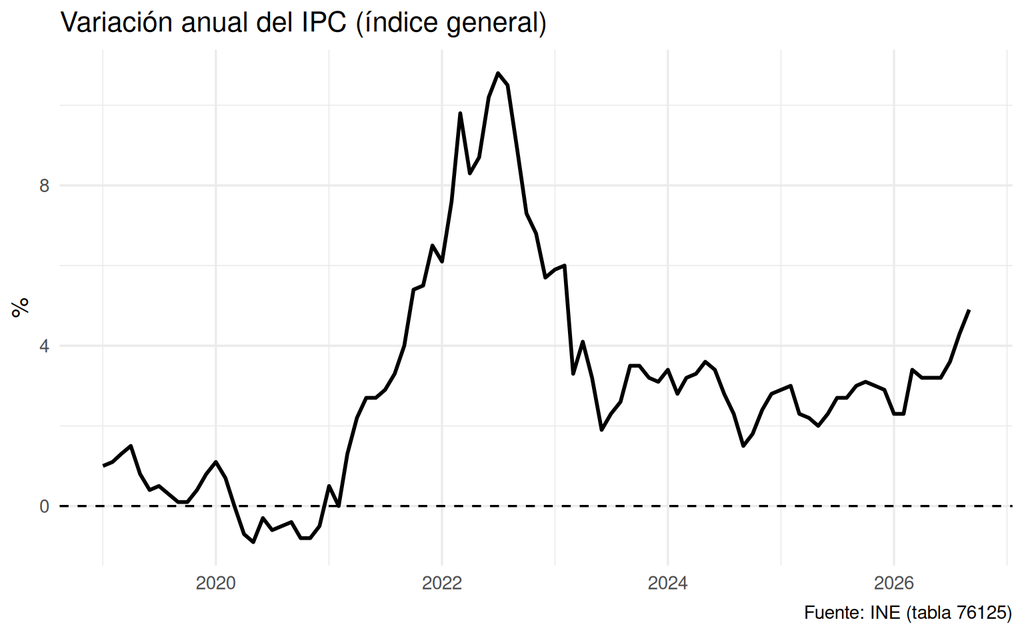

```r
df_ipc %>%
  mutate(fecha = as.Date(Fecha)) %>%
  ggplot(aes(x = fecha, y = Valor)) +
  geom_line(linewidth = 1) +
  geom_hline(yintercept = 0, linetype = "dashed") +
  labs(title = "Variación anual del IPC (índice general)",
       x = NULL, y = "%",
       caption = "Fuente: INE (tabla 76125)")
```

## `filter` con atajos

- Buscar los identificadores es pesado. Para las “variables” más habituales hay atajos, y se puede filtrar por el nombre del valor. Por ejemplo, la inflación de la slide anterior:

```r
#- con los números:
my_filtro <- list("3" = "74", "762" = "304092")

#- con atajos (lo mismo):
my_filtro <- list(tipodato = "Variación anual", grupo = "Índice general")
```

- Los atajos disponibles (`tipodato`, `grupo`, `sexo`, `edad`, `ccaa`, `prov`, …) se ven con `get_filter_shortcuts()`
- Otro ejemplo, con la tabla del paro de la EPA (`65334`):

```r
df_paro <- get_data_table(idTable = 65334, nlast = 1, unnest = TRUE, tip = "AM", metanames = TRUE,
                          filter = list(sexo = "Ambos sexos", edad = "Total"))

df_paro %>% as_tibble() %>%
  select(Comunidades.y.Ciudades.Autónomas, Sexo, Edad, T3_Periodo, Anyo, Valor) %>% slice(1:3)
```

| Comunidades.y.Ciudades.Autónomas <chr> | Sexo <chr> | Edad <chr> | T3_Periodo <chr> | Anyo <int> | Valor <dbl> |
| --- | --- | --- | --- | --- | --- |
| Total Nacional | Ambos sexos | Total | T3 | 2026 | 10.18 |
| Andalucía | Ambos sexos | Total | T3 | 2026 | 14.91 |
| Aragón | Ambos sexos | Total | T3 | 2026 | 9.23 |

## Cosas a tener en cuenta

- No todo INEbase está en la API: si una operación no aparece en `get_metadata_operations()`, toca descargar el fichero a mano
- El último dato puede ser un **avance**: el INE publica primero el índice general y días después el detalle. Mientras tanto, el resto de series tienen `NA` en ese periodo
- Los identificadores cambian: cuando el INE cambia la base de una estadística crea tablas nuevas. Si un script antiguo deja de traer datos recientes, mira si hay una tabla nueva
- Guarda en disco lo que descargues (`rio::export()`): así el análisis no depende de tener conexión

## Tarea: ¿qué precios suben más?

- Tarea
- Pistas
- Solución
- Gráfico
- Con la tabla [`76125`](https://www.ine.es/jaxiT3/Tabla.htm?t=76125) del IPC (*Índices nacionales: general y de grupos ECOICOP*):
1. Descarga los 3 últimos meses de la **variación anual** de todos los grupos, con una columna para el nombre del grupo
2. Quédate con el último mes que tenga datos para todos los grupos
3. Ordena los grupos de mayor a menor subida de precios. ¿Qué grupo sube más? ¿Y menos?
4. [🌶] Haz un gráfico de barras con la variación anual de cada grupo
- 1: `filter = list("3" = "74")`, con `tip = "AM"` y `metanames = TRUE`
- 2: si el último mes es un dato avance, los grupos tendrán `NA`: quítalos antes de quedarte con la fecha más reciente
- 3: `arrange(desc(Valor))`
- 4: `geom_col()`, con `fct_reorder()` para ordenar las barras

```r
df_grupos <- get_data_table(idTable = 76125, nlast = 3, unnest = TRUE,
                            tip = "AM", metanames = TRUE, filter = list("3" = "74")) %>%
  as_tibble() %>%
  mutate(fecha = as.Date(Fecha)) %>%
  select(grupo = Grupos.ECOICOP.ver.2, fecha, var_anual = Valor) %>%
  filter(!is.na(var_anual)) %>%
  group_by(fecha) %>% filter(n() > 1) %>% ungroup() %>%
  filter(fecha == max(fecha)) %>%
  arrange(desc(var_anual))
```

**1**

Quitamos los `NA` y los meses que solo tienen el índice general (los datos avance)

```r
df_grupos %>% slice(1:4)
```

| grupo <chr> | fecha <date> | var_anual <dbl> |
| --- | --- | --- |
| Transporte | 2026-09-01 | 10.5 |
| Vivienda, agua, electricidad, gas y otros combustibles | 2026-09-01 | 7.2 |
| Índice general | 2026-09-01 | 4.9 |
| Restaurantes y servicios de alojamiento | 2026-09-01 | 4.9 |

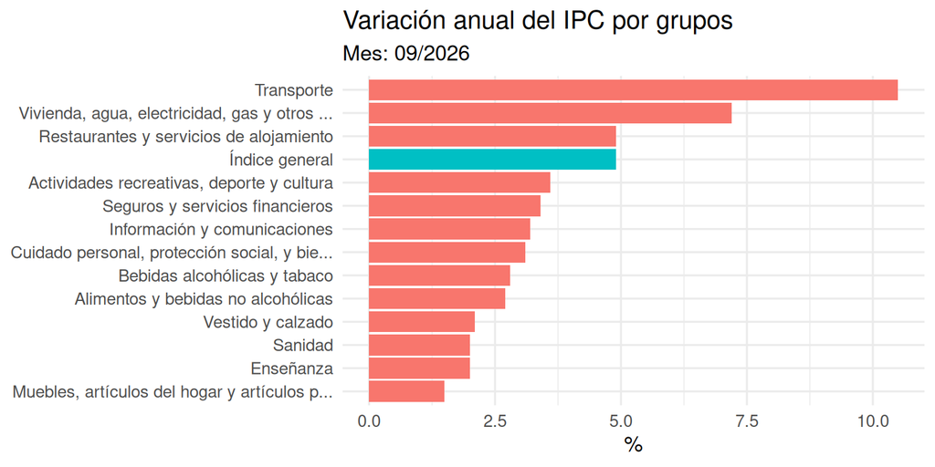

```r
df_grupos %>%
  mutate(grupo = str_trunc(grupo, 45)) %>%
  ggplot(aes(x = var_anual, y = fct_reorder(grupo, var_anual))) +
  geom_col(aes(fill = grupo == "Índice general"), show.legend = FALSE) +
  labs(title = "Variación anual del IPC por grupos",
       subtitle = paste("Mes:", format(max(df_grupos$fecha), "%m/%Y")), x = "%", y = NULL)
```

## Tarea: el paro de los jóvenes

- Tarea
- Pistas
- Solución (1)
- Solución (2-3)
- Solución (4)
- Con la tabla [`65334`](https://www.ine.es/jaxiT3/Tabla.htm?t=65334) de la EPA (*Tasas de paro por distintos grupos de edad, sexo y comunidad autónoma*):
1. Averigua qué “variables” tiene la tabla y qué valores toma la “variable” *Edad*
2. Descarga la tasa de paro de los **menores de 25 años** (ambos sexos) de todas las comunidades, desde 2008
3. ¿Qué 3 comunidades tienen la tasa de paro juvenil más alta en el último trimestre?
4. [🌶] Dibuja la evolución de la tasa de paro juvenil en la Comunitat Valenciana y en el total nacional
- 1: `get_metadata_table_groups()` y `get_metadata_table_values()`
- 2: en `filter` puedes usar los atajos y el nombre del valor: `edad = "Menores de 25 años"`
- 3: `filter(fecha == max(fecha))` y `slice_max()`
- 4: `filter(ccaa %in% c(...))` y `geom_line(aes(color = ccaa))`

```r
get_metadata_table_groups(idTable = 65334)
```

| Id <int> | Nombre <chr> |
| --- | --- |
| 133219 | Sexo |
| 133220 | Comunidades y Ciudades Autónomas |
| 133221 | Edad |

```r
get_metadata_table_values(idTable = 65334,
                          idGroup = 133221) %>%
  select(Id, Fk_Variable, Nombre)
```

| Id <int> | Fk_Variable <int> | Nombre <chr> |
| --- | --- | --- |
| 15668 | 356 | Total |
| 10568 | 357 | Menores de 25 años |
| 10569 | 357 | 25 y más años |
| 10553 | 360 | De 16 a 19 años |
| 15661 | 360 | De 20 a 24 años |
| 10561 | 360 | De 25 a 54 años |
| 10560 | 357 | De 55 y más años |

```r
df_jov <- get_data_table(idTable = 65334, unnest = TRUE, tip = "AM", metanames = TRUE,
                         dateStart = "2008/01/01",
                         filter = list(sexo = "Ambos sexos", edad = "Menores de 25 años")) %>%
  as_tibble() %>%
  mutate(fecha = as.Date(Fecha)) %>%
  select(ccaa = Comunidades.y.Ciudades.Autónomas, fecha, tasa_paro = Valor)
```

```r
df_jov %>%
  filter(fecha == max(fecha)) %>%
  slice_max(tasa_paro, n = 3)
```

| ccaa <chr> | fecha <date> | tasa_paro <dbl> |
| --- | --- | --- |
| Melilla | 2026-07-01 | 42.54 |
| Extremadura | 2026-07-01 | 34.24 |
| Rioja, La | 2026-07-01 | 30.7 |

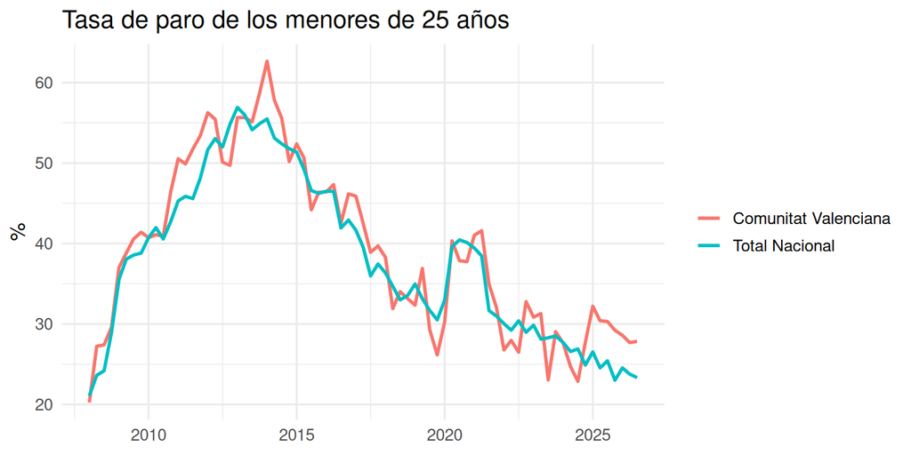

```r
df_jov %>%
  filter(ccaa %in% c("Comunitat Valenciana", "Total Nacional")) %>%
  ggplot(aes(x = fecha, y = tasa_paro, color = ccaa)) +
  geom_line(linewidth = 1) +
  labs(title = "Tasa de paro de los menores de 25 años", x = NULL, y = "%", color = NULL)
```

## Para saber más

- La [web del paquete `ineapir`](https://es-ine.github.io/ineapir/), con sus tutoriales, y su [cheatsheet](https://raw.githubusercontent.com/es-ine/ineapir/main/man/figures/ineapir.pdf)
- La [documentación de la API](https://www.ine.es/dyngs/DAB/index.htm?cid=1099) del INE
- [INEbase](https://www.ine.es/dyngs/INEbase/listaoperaciones.htm): la lista completa de operaciones, por temas
- El [calendario de publicaciones](https://www.ine.es/daco/daco41/calen.htm) del INE: qué día sale cada dato
- Para datos de otros países: el paquete [eurostat](https://ropengov.github.io/eurostat/) (lo vimos en las slides 04B)

## Resumen

| Para … | usamos … |
| --- | --- |
| encontrar una tabla | [INEbase](https://www.ine.es/dyngs/INEbase/listaoperaciones.htm): el identificador es el `t=` de la url |
| descargar su fichero | `https://www.ine.es/jaxiT3/files/t/es/csv_bdsc/`*id*`.csv` (o `.../px/`*id*`.px`) |
| importarlo | `read_csv2(ruta, na = "..")` |
| … o mejor, el fichero PC-Axis | `pxR::read.px(url) %>% as.data.frame()` |
| limpiarlo | `janitor::clean_names()`, `separate()` o `str_extract()`, `lubridate::yq()` / `ym()` |
| buscar operaciones y tablas desde R | `get_metadata_operations()`, `get_metadata_tables_operation()` |
| ver qué contiene una tabla | `get_metadata_table_groups()`, `get_metadata_table_values()` |
| descargar una tabla | `get_data_table(idTable, unnest = TRUE, tip = "AM", metanames = TRUE)` |
| … solo unos periodos | `nlast`, `dateStart`, `dateEnd` |
| … solo unas categorías | `filter = list(...)` |